# An Empirical Network Analysis of Computer Science Collaborations

Author

Raunak Advani

Published

August 7, 2023

`Keywords`

Networks, Network Analysis, Data Science, Literature Review, Collaborations, Citations, Computer Science, dplb, Python, NetworkX, Graph Theory

# Abstract

Scientific collaborations, evident in co-authorships, are essential to the progression of research, particularly in the rapidly evolving field of computer science, which encapsulates ancillary areas such as artificial intelligence, computer vision, and analytics. These areas, among others, experience a rapid pace of development and innovation, making the study of their collaborative networks essential for understanding the dynamics of knowledge production and dissemination. This paper delves into the intricate landscape of these collaborations by leveraging the dblp dataset, an exhaustive compilation of bibliographic data concerning computer science papers.

The central aim is to construct and scrutinize the collaboration networks among authors, essentially transforming raw, bibliographic data into a meaningful, interconnected web of knowledge. To conduct this analysis, I employ Python and NetworkX, a robust library designed for the study of complex networks. These tools will allow me to apply various network analysis techniques, such as centrality measures for identifying key contributors and community detection algorithms for uncovering clustering patterns.

The insights gleaned from this project promise to illuminate the structure of scientific collaborations in computer science, highlighting influential clusters and key contributors within the network. Furthermore, our findings could significantly contribute to our understanding of the implications of these collaborations for knowledge production and dissemination in computer science. This study builds upon previous research in the field, advancing the growing body of literature on scientific collaboration networks. By providing a comprehensive analysis of the co-authorship network in computer science, I aspire to shed light on the structural and dynamic aspects of these collaborations, with potential implications for guiding policies related to research collaborations, identifying emerging research trends, and assisting early-career researchers in their career development.

# Introduction

The impact of collaborations in the realm of scientific research is profound and far-reaching, influencing the trajectory of knowledge generation and dissemination. This is especially pronounced in the field of computer science, which is one that is characterized by rapid advancements and cross-disciplinary applications. As collaborations form the cornerstone of novel research outputs, understanding the structure, dynamics, and implications of these collaborative networks becomes crucial.

Scientific collaboration networks function as the backbone of knowledge creation, fostering innovation through shared expertise and synergistic efforts. In his paper on scientific collaborations, Newman explored such networks and found that they form ‘small worlds’ - networks in which randomly chosen pairs of scientists are typically separated by only a short path of intermediate acquaintances (Newman 2001). This property, coupled with high clustering and well- defined community structures, results in an efficient structure for information exchange, thereby accelerating the pace of innovation.

Building upon this foundational understanding, my paper aims to navigate the complex landscape of scientific collaboration within the field of computer science. I leverage the dblp dataset, a rich repository of bibliographic information on computer science papers spanning various journals and conferences. The dataset serves as the raw material from which I construct my collaboration network.

My study revolves around several key questions: What drives collaboration within the network? Which authors hold central positions within the network, thereby exerting significant influence over information flow? How do authors cluster based on their collaboration patterns? Answers to these questions will shed light on the underlying structure of the collaboration network and further provide insights into the knowledge exchange dynamics in the field of computer science.

This project utilizes Python and NetworkX, a powerful library for the creation, manipulation, and study of the structure, dynamics, and functions of complex networks. Through these tools, I aim to transform the raw bibliographic data from the dblp dataset into an interpretable collaboration network. I will employ various network analysis techniques, including centrality measures to identify key contributors, and community detection algorithms to uncover clustering patterns.

My research builds upon the work of previous studies and contributes to the growing body of literature on scientific collaboration networks. For instance, Wenwen et al. studied collaboration networks in the field of adolescent myopia prevention and control, revealing the positive influence of ‘academic wanderers’ on research performance (Wenwen et al. 2019). By extending this line of research to the computer science domain, my project aims to provide a comprehensive understanding of collaboration patterns and their implications for research output and impact.

The dblp dataset, which serves as the crux of our investigation, is an invaluable resource that captures the breadth and depth of research collaborations in computer science. It provides comprehensive bibliographic information, including the authors, publication venues (journals and conferences), publication year, and abstracts. This vast and multidimensional dataset presents an opportunity to delve into the rich tapestry of collaborations and knowledge exchange patterns in computer science.

One of the unique aspects of our study is the application of network analysis techniques to represent and analyze co-authorship patterns. Co-authorship networks are a specific type of social network where nodes represent authors and edges represent collaborative relationships. These networks can illuminate several aspects of scientific collaboration: the degree of collaboration (represented by the number of edges connecting to a node), the importance of a researcher within the network (using centrality measures), the grouping of researchers into distinct communities (using community detection algorithms), and the overall structure and connectivity of the network (using network visualization techniques).

My study implements several measures to uncover the dynamics of the co-authorship network. One such measure is centrality, a key concept in network analysis that quantifies the importance of a node within a network. In the context of co-authorship networks, centrality measures can identify key contributors, those authors who are most central to the network and thus, potentially, have a significant influence on the field. We will use a combination of degree centrality, closeness centrality, and betweenness centrality to unravel the complex dynamics of influence within the collaboration network.

Community detection is another vital aspect of my analysis. Communities in a network are groups of nodes that are more densely connected to each other than to other nodes in the network. In the context of co-authorship networks, communities could signify groups of authors who frequently collaborate with each other. Identifying these communities can provide insights into the collaboration patterns within the field and help understand how research groups form and evolve over time.

This research contributes to the burgeoning field of network science, which has found applications in various domains, from social media analysis to epidemiology. Specifically, this work adds to the body of literature on co-authorship networks, which have been studied in various scientific disciplines. By focusing on computer science, a field characterized by rapid advancements and cross-disciplinary collaborations, I hope to provide unique insights into the collaboration patterns and dynamics in this area.

Finally, the implications of this study go beyond understanding the structure and dynamics of co-authorship networks in computer science. They could potentially inform policies related to research collaborations, help identify emerging research trends, and guide young researchers in their career development. For instance, understanding the key contributors in the field could help early-career researchers identify potential mentors or collaborators. Similarly, understanding the collaboration patterns could help institutions and funding agencies design policies that promote effective collaborations.

By providing a comprehensive analysis of the co-authorship network in computer science, I aim to contribute to our understanding of scientific collaborations and their role in knowledge creation and dissemination. I believe that my study, with its combination of data science techniques and a rich dataset, provides a promising approach to investigating the landscape of scientific collaborations.

In conclusion, this project endeavors to elucidate the complex web of scientific collaborations in computer science. Through the lens of network analysis, I aspire to shed light on the structure and dynamics of these collaborations, thereby contributing to our understanding of how knowledge is created and disseminated in this vital field.

# Methods

[output not shown]

## Data Extraction

Data for the study is extracted from the DBLP computer science bibliography database (Ley 2002) using the DBLP parser, which is a script used to extract every paper in the dataset, with relevant information of the papers such as the paper type (journal, article, conference, etc), data published, authors, and title. The parser is used to generate separate CSV files for each type of article present in the database.

## Data Munging

The next critical stage of the process is munging the data for my specific needs. The separate CSV files are merged together into a single dataset using `Python` and the `Pandas` library. The resulting dataset is then cleaned to remove unnecessary information and improve readability. Fields such as citations, year of publication, and article type are deleted as they are not required for the subsequent network analysis. The data cleaning process also helps with managing memory usage, an important consideration given the large size of the dataset and the breadth of analysis covered.

## Network Creation

A co-authorship network is then created from the cleaned dataset using the `NetworkX` library. Each node in the network represents an author, and an edge between two nodes signifies a collaboration between the two corresponding authors. I use k-core decomposition to extract the ‘dense’ part of the network, essentially pruning the network to only include nodes with a degree of k (50) or higher. K-core decomposition (Seidman 1983) is a method used in network theory to simplify complex, dense networks, allowing us to focus on the most interconnected authors. Given that the original network contained over 2 million authors, this step reduces the network to a more manageable size.

## Statistical Analyses

I conduct a range of statistical tests to explore the structure and characteristics of the co-authorship network. This includes community detection with the Louvain method (Blondel et al. 2008), where I identify groups of authors who collaborate more frequently with each other than with authors outside their group. I use betweenness centrality to identify authors who serve as bridges between different paths of the network, and density to measure the proportion of potential connections in the network that are actually present.

Community detection can reveal the substructure of the collaboration network and help identify closely-knit research groups. Betweenness centrality can highlight authors who play a key role in connecting different communities, while the network’s density provides a measure of overall interconnectedness among authors.

## Named Entity Recognition

To explore the research topics of the identified communities, I apply Named Entity Recognition `(NER)` to the titles of papers authored by members of each community. NER is a process in Natural Language Processing `(NLP)` that identifies and classifies named entities in text, such as names of people, organization, locations, expressions of times, quantities, and other types of entities. In this case, I use NER to extract key terms from paper titles, which allow me to identify the main research themes within each community. Comparing the extracted entities provides insights into the similarities and differences in research focus among different groups of authors.

# Results and Discussion

This study of the co-authorship network yields several interesting findings. As a first step in my analysis, I visualise the degree distribution of the network, which demonstrates a power-law-like behavior, typical of many real-world networks (Barabási and Albert 1999). This is a key characteristic of scale-free networks, where most nodes have a few connections, while a small number of nodes (“hubs”) have a large number of connections. In the context of the co-authorship network, this indicates that while most authors collaborate with a small number of other authors, there are a few prolific authors who collaborate with a large number of different authors.

A power-law degree distribution thus suggests that the co-authorship network is not a random network, but rather a complex network with a rich and intricate structure. This motivates further examination of the network’s properties and the roles individual nodes play in the network’s connectivity and information flow.

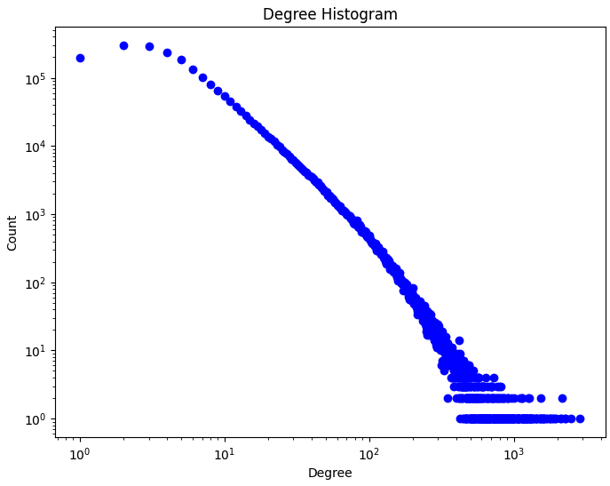

Figure 1: Network Degree Distribution

## Centrality Measures

Centrality measures are a key tool for identifying the most important nodes within a network. In our co-authorship network, these nodes represent authors who are critical to the structure and function of the network.

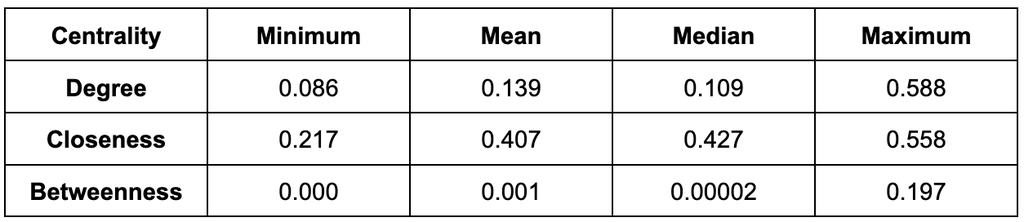

Figure 2: Network Centrality Results

The above figure displays the various centrality measures for the network. The degree centrality of a node represents how connected a node is, in terms of the number of neighbors it has. In our network, the degree centrality ranges from 0.086 to 0.588, with an average value of 0.139. This suggests that while most authors have a moderate number of collaborators, a few authors (those with high degree centrality) have collaborated with a significant number of different authors. These highly connected authors may be influential in the field, given their extensive collaborations.

Closeness centrality is a measure of how ‘close’ nodes in a network are, eliciting the ease of information flow. In this context, an author with high closeness centrality has a short average collaborative path to all other authors. The closeness centrality values in the network range from 0.217 to 0.558, with an average value of 0.407. This suggests that, on average, authors are relatively close to each other in terms of collaborative paths, which can be an indication of a highly interconnected community of researchers.

Lastly, betweenness centrality quantifies the number of times a node acts as a bridge along the shortest path between two other nodes. In our context, authors with high betweenness centrality are those who frequently collaborate with authors who do not collaborate with each other. These authors could be seen as bringing together disparate parts of the network. The betweenness centrality in our network ranges from 0 to 0.197, with an average value close to 0 (0.001), suggesting that few authors act as these critical bridges. This could indicate that collaborations tend to occur within, rather than between, different research communities.

## Community Detection

In order to gain further insights into the structure of the co-authorship network, I employ community detection, a method used to identify the clusters or groups within the network. Specifically, I utilize the Louvain method (Blondel et al. 2008) for community detection, a widely used technique for its effectiveness and efficiency. The Louvain method is a hierarchical clustering algorithm that optimizes the modularity of the network, which is a measure that indicates the strength of division of a network into communities. Applying the Louvain method to my network results in the detection of seven communities, each in varying size. The distribution of nodes, i.e. authors, across these communities is as follows:

- Community 0: 222 nodes
- Community 1: 213 nodes
- Community 2: 186 nodes
- Community 3: 128 nodes
- Community 4: 202 nodes
- Community 5: 102 nodes
- Community 6: 115 nodes

These communities represent distinct clusters of authors who frequently collaborate with each other. The sizes of the communities are quite diverse, suggesting varying scales of collaboration groups within the field. The identification of these communities not only sheds light on collaboration patterns, but also sets the stage for further analysis, such as investigating the research focus for various clusters of researchers using Named Entity Recognition.

## Named Entity Recognition

In the final part of my analysis, I implement Named Entity Recognition (NER) to delve deeper in to the research focus of the authors with the highest and lowest degree centrality. NER is a substack of information extraction which seeks to classify named entitites mentioned in unstructured text into predefined categories such as names, orgnizations, quantities, locations, time expressions, etc.

I apply NER to the titles of papers authored by the five authors with the highest degree centrality and the five authors with the lowest degree centrality. The aim is to identify the most frequently occurring entities in the authors’ papers, which could provide insights into their research areas and possibly explain their collaboration patterns.

I find a high degree of similarity (average cosine similarity of ~0.9) among the entities associated with the papers of the authors with the highest degree centrality. This could suggest that these authors are engaged in very similar or closely related research areas, which might explain their high number of collaborations. If authors are working in similar fields, they may have more opportunities to collaborate and co-author papers.

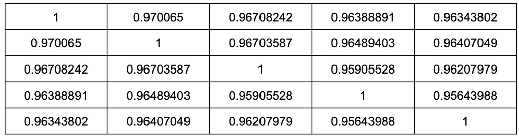

Figure 3: Cosine Similarities for the top 5 authors, by degree centrality

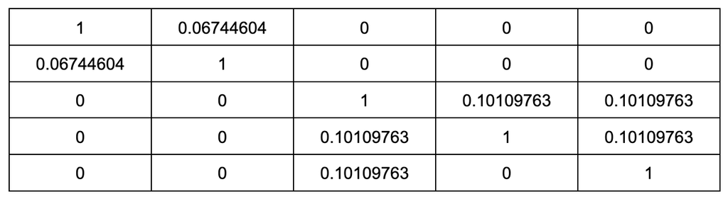

Figure 4: Cosine Similarities for the bottom 5 authors, by degree centrality

Thus, the NER analysis and subsequent cosine similarity calculations offer interesting insights into the potential reasons behind the collaboration patterns observed in the network. They suggest that research focus, as reflected in paper titles, could play a significant role in shaping collaborations among other.

In the future, more comprehensive analyses could be conducted by applying NER to abstracts or full texts of papers (if available), as they would provide a more detailed representation of the authors’ research areas. Additionally, other factors such as geographical location, institutional affiliation, and number of citations could also be investigated for their influence on collaboration patterns.

# Conclusions

My study set out to explore the intricate structure of a co-authorship network in computer science, using comprehensive data from the DBLP database. My analysis examined several facets of the network structure, including centrality measures, community detection, and text analysis of paper titles, to gain insights into the patterns of collaboration among authors.

This study offers valuable insights into collaboration patterns in computer science and introduces a novel approach to understanding the dynamics of scientific collaborations. My findings indicate that both network structure and research focus can significantly influence collaboration patterns.

However, this study only scratches the surface of the complex phenomenon of scientific collaborations. Future research could consider a more comprehensive text analysis, considering abstracts or full texts of papers, or investigate other factors such as geographical location or number of citations. By continuing to explore these complex networks, we can deepen our understanding of scientific collaborations, which could have implications for research policy, scientific discovery, and innovation.

In conclusion, this study underscores the utility of network analysis and natural language processing in shedding light on scientific collaborations. As the scientific landscape continues to evolve, such computational approaches will undoubtedly play a crucial role in understanding and shaping the future of scientific research.

## References

Barabási, Albert-László, and Réka Albert. 1999. “Emergence of Scaling in Random Networks.” *Science* 286 (5439): 509–12.

Blondel, Vincent D, Jean-Loup Guillaume, Renaud Lambiotte, and Etienne Lefebvre. 2008. “Fast Unfolding of Communities in Large Networks.” *Journal of Statistical Mechanics: Theory and Experiment* 2008 (10): P10008.

Ley, Michael. 2002. “The DBLP Computer Science Bibliography: Evolution, Research Issues, Perspectives.” In *International Symposium on String Processing and Information Retrieval*, 1–10. Springer.

Newman, Mark EJ. 2001. “The Structure of Scientific Collaboration Networks.” *Proceedings of the National Academy of Sciences* 98 (2): 404–9.

Seidman, Stephen B. 1983. “Network Structure and Minimum Degree.” *Social Networks* 5 (3): 269–87.

Wenwen, WU, XIE Yaofei, LIU Xiangxiang, GU Yaohua, Yuting Zhang, TU Xinlong, and TAN Xiaodong. 2019. “Analysis of Scientific Collaboration Networks Among Authors, Institutions, and Countries Studying Adolescent Myopia Prevention and Control: A Review Article.” *Iranian Journal of Public Health* 48 (4): 621.